## Setup

### Load packages

```r
library(ggplot2)
library(dplyr)
library(statsr)
library(BAS)
library(MASS)
library(broom)
library(tidyverse)
```

### Load data

```r
load("movies.Rdata")
```

## Part 1: Data

The dataset “movies” contains 651 movies produced and released before 2016. 32 variables are included to present a movie’s information.

### On Generabizability:

All movies are randomly sampled. So the result of this analysis can be generalized to draw conclusions for other movies.

One possible source of bias is from the period of time which the movies is produced, from 1970 to 2014. 40 years can easily fit 3 generations in it. And we can expect the taste of the audience can change really fast. So the vote and rating might favor latter movies than the ones in the 70s.

### On Causality:

The sample is the product of observing randomly chosen movies. There is no random assignment. Therefor, no causality can be concluded from analysing this dataset.

## Part 2: Data manipulation

We need a editted dataset which contains the following variables:

- **feature_film**: “yes” if title_type is Feature Film, “no” otherwise
- **drama**: “yes” if genre is Drama, “no” otherwise
- runtime: Runtime of movie (in minutes)
- **mpaa_rating_R**: “yes” if mpaa_rating is R, “no” otherwise
- thtr_rel_year: Year the movie is released in theaters
- **oscar_season**: “yes” if movie is released in November, October, or December (based on thtr_rel_month), “no” otherwise
- **summer_season**: “yes” if movie is released in May, June, July, or August (based on thtr_rel_month), “no” otherwise
- imdb_rating: Rating on IMDB
- imdb_num_votes: Number of votes on IMDB
- critics_score: Critics score on Rotten Tomatoes
- best_pic_nom: Whether or not the movie was nominated for a best picture Oscar (no, yes)
- best_pic_win: Whether or not the movie won a best picture Oscar (no, yes)
- best_actor_win: Whether or not one of the main actors in the movie ever won an Oscar (no, yes) – note that this is not necessarily whether the actor won an Oscar for their role in the given movie
- best_actress_win: Whether or not one of the main actresses in the movie ever won an Oscar (no, yes) – note that this is not necessarily whether the actresses won an Oscar for their role in the given movie
- best_dir_win: Whether or not the director of the movie ever won an Oscar (no, yes) – note that this is not necessarily whether the director won an Oscar for the given movie
- top200_box: Whether or not the movie is in the Top 200 Box Office list on BoxOfficeMojo (no, yes)
- audience_score: Audience score on Rotten Tomatoes (The response variable)

The ones in **bold** are new variables which will construct base on other variables in the original dataset.  
And the others will be just copied from the original.

```r
movies_edited <- movies %>%
  mutate(feature_film = factor(ifelse(title_type == 'Feature Film', 'yes', 'no'))) %>%
  mutate(drama = factor(ifelse(genre == 'Drama', 'yes', 'no'))) %>%
  mutate(mpaa_rating_R = factor(ifelse(mpaa_rating == 'R', 'yes', 'no'))) %>%
  mutate(oscar_season = factor(ifelse(thtr_rel_month %in% c(10, 11, 12), 'yes', 'no'))) %>%
  mutate(summer_season = factor(ifelse(thtr_rel_month %in% c(5, 6, 7, 8), 'yes', 'no'))) %>%
  dplyr::select(feature_film, drama, runtime, mpaa_rating_R, thtr_rel_year, oscar_season, summer_season,
                imdb_rating, imdb_num_votes, critics_score, best_pic_nom, best_pic_win, best_actor_win,
                best_actress_win, best_dir_win, top200_box, audience_score)

summary(movies_edited)
```

```
##  feature_film drama        runtime    mpaa_rating_R thtr_rel_year  oscar_season summer_season
##  no : 60      no :346   Min.   : 39   no :322       Min.   :1970   no :460      no :443
##  yes:591      yes:305   1st Qu.: 92   yes:329       1st Qu.:1990   yes:191      yes:208
##                         Median :103                 Median :2000
##                         Mean   :106                 Mean   :1998
##                         3rd Qu.:116                 3rd Qu.:2007
##                         Max.   :267                 Max.   :2014
##                         NA's   :1
##   imdb_rating   imdb_num_votes   critics_score   best_pic_nom best_pic_win best_actor_win
##  Min.   :1.90   Min.   :   180   Min.   :  1.0   no :629      no :644      no :558
##  1st Qu.:5.90   1st Qu.:  4546   1st Qu.: 33.0   yes: 22      yes:  7      yes: 93
##  Median :6.60   Median : 15116   Median : 61.0
##  Mean   :6.49   Mean   : 57533   Mean   : 57.7
##  3rd Qu.:7.30   3rd Qu.: 58300   3rd Qu.: 83.0
##  Max.   :9.00   Max.   :893008   Max.   :100.0
##
##  best_actress_win best_dir_win top200_box audience_score
##  no :579          no :608      no :636    Min.   :11.0
##  yes: 72          yes: 43      yes: 15    1st Qu.:46.0
##                                           Median :65.0
##                                           Mean   :62.4
##                                           3rd Qu.:80.0
##                                           Max.   :97.0
##
```

With this dataset, we finish our Data Manipulation part. And we are ready to use this dataset for the next part, EDA.

## Part 3: Exploratory data analysis

### 1. Explore the response variable *audience_score*:

```r
summary(movies_edited$audience_score)
```

```
##    Min. 1st Qu.  Median    Mean 3rd Qu.    Max.
##    11.0    46.0    65.0    62.4    80.0    97.0
```

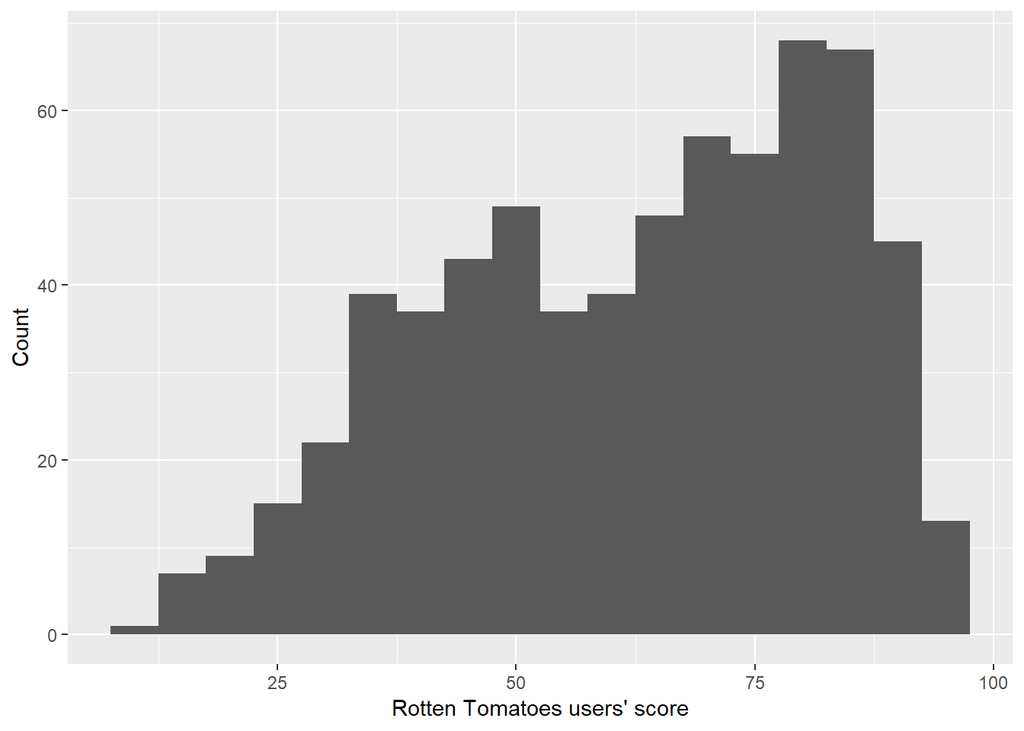

```r
ggplot(data = movies_edited, aes(x = audience_score)) +
  geom_histogram(binwidth = 5) +
  labs(x = 'Rotten Tomatoes users\' score', y= 'Count')
```

The distribution of audience_score is slightly left-skewed. With mean and median are 62.36 and 65 respectively.  
Since the skewness is not severe, no transformation is needed for audience_score.

### 2. Explore the relationship between *audience_score* and one of the newly created variable *drama*:

Drama is no doubt a popular genre. In this dataset, the percentage of drama genre film is nearly 47%. Well, no one want to watch a boring, monotone movie anyway.  
It seems that *drama* can be a good predictor for *audience_score*. Let’s see how is the correlation between *drama* and *audience_score*.

```r
summary(lm(audience_score ~ drama, data = movies_edited))
```

```
##
## Call:
## lm(formula = audience_score ~ drama, data = movies_edited)
##
## Residuals:
##    Min     1Q Median     3Q    Max
## -52.35 -16.35   3.27  15.96  37.27
##
## Coefficients:
##             Estimate Std. Error t value Pr(>|t|)
## (Intercept)    59.73       1.08   55.44  < 2e-16 ***
## dramayes        5.62       1.57    3.57  0.00039 ***
## ---
## Signif. codes:  0 '***' 0.001 '**' 0.01 '*' 0.05 '.' 0.1 ' ' 1
##
## Residual standard error: 20 on 649 degrees of freedom
## Multiple R-squared:  0.0192, Adjusted R-squared:  0.0177
## F-statistic: 12.7 on 1 and 649 DF,  p-value: 0.000387
```

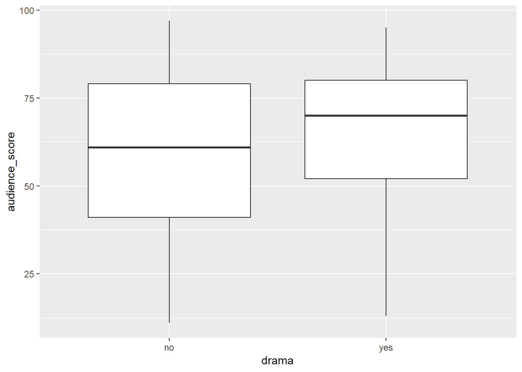

```r
ggplot(data = movies_edited, aes(x = drama, y = audience_score)) +
  geom_boxplot()
```

We can say that *drama* is a statistical significant explanatory variable. And there is a positive correlation relationship between *drama* and *audience_score*.  
But with such a tiny R squared score, we can’t use this simple model to predict *audience_score*.

We will need something more complicated. In the next part, we will build a multivariate Bayesian regression model, which will consider all the explanatory variables in the dataset.

## Part 4: Modeling

### 1. Model selection:

#### First, let’s implement Bayesian model averaging:

```r
bma_model <- bas.lm(audience_score ~ ., data = na.omit(movies_edited),
                    prior = "ZS-null", modelprior = uniform())
summary(bma_model)
```

```
##                     P(B != 0 | Y)  model 1  model 2  model 3  model 4  model 5
## Intercept                 1.00000   1.0000   1.0000   1.0000   1.0000   1.0000
## feature_filmyes           0.06797   0.0000   0.0000   0.0000   0.0000   0.0000
## dramayes                  0.04592   0.0000   0.0000   0.0000   0.0000   0.0000
## runtime                   0.46420   0.0000   1.0000   0.0000   0.0000   1.0000
## mpaa_rating_Ryes          0.20274   0.0000   0.0000   0.0000   1.0000   1.0000
## thtr_rel_year             0.09500   0.0000   0.0000   0.0000   0.0000   0.0000
## oscar_seasonyes           0.07750   0.0000   0.0000   0.0000   0.0000   0.0000
## summer_seasonyes          0.08336   0.0000   0.0000   0.0000   0.0000   0.0000
## imdb_rating               1.00000   1.0000   1.0000   1.0000   1.0000   1.0000
## imdb_num_votes            0.06115   0.0000   0.0000   0.0000   0.0000   0.0000
## critics_score             0.88079   1.0000   1.0000   1.0000   1.0000   1.0000
## best_pic_nomyes           0.13685   0.0000   0.0000   0.0000   0.0000   0.0000
## best_pic_winyes           0.04216   0.0000   0.0000   0.0000   0.0000   0.0000
## best_actor_winyes         0.14642   0.0000   0.0000   1.0000   0.0000   0.0000
## best_actress_winyes       0.14444   0.0000   0.0000   0.0000   0.0000   0.0000
## best_dir_winyes           0.06936   0.0000   0.0000   0.0000   0.0000   0.0000
## top200_boxyes             0.04999   0.0000   0.0000   0.0000   0.0000   0.0000
## BF                             NA   1.0000   0.8703   0.2237   0.2218   0.2056
## PostProbs                      NA   0.1388   0.1208   0.0311   0.0308   0.0285
## R2                             NA   0.7525   0.7549   0.7539   0.7539   0.7563
## dim                            NA   3.0000   4.0000   4.0000   4.0000   5.0000
## logmarg                        NA 443.9495 443.8106 442.4519 442.4433 442.3676
```

The posterior model inclusion probability for some variables are very small, like *feature_film* or *best_pic_win*.  
Clearly including all variables is not the best model.

#### Second, choosing the best model:

Since our goal is to use the model to predict *audience_score*, the best model will be *Best Predictive Model*

```r
best_model <- predict(bma_model, estimator = 'BPM', se.fit = TRUE)
variable.names(best_model)
```

```
## [1] "Intercept"     "runtime"       "imdb_rating"   "critics_score"
```

#### Finally, we have our model:

```r
bpm_model <- bas.lm(audience_score ~ runtime + imdb_rating + critics_score, data = na.omit(movies_edited),
                    prior = 'ZS-null', modelprior = uniform())
```

The model consist of 3 explanatory variables:

- runtime
- imdb_rating
- critics_score

### 2. Model diagnostics:

```r
summary(bpm_model)
```

```
##               P(B != 0 | Y)  model 1  model 2  model 3  model 4   model 5
## Intercept            1.0000   1.0000   1.0000   1.0000   1.0000 1.000e+00
## runtime              0.4724   0.0000   1.0000   1.0000   0.0000 0.000e+00
## imdb_rating          1.0000   1.0000   1.0000   1.0000   1.0000 0.000e+00
## critics_score        0.8855   1.0000   1.0000   0.0000   0.0000 1.000e+00
## BF                       NA   1.0000   0.8703   0.1276   0.1143 3.900e-99
## PostProbs                NA   0.4735   0.4120   0.0604   0.0541 0.000e+00
## R2                       NA   0.7525   0.7549   0.7509   0.7481 4.958e-01
## dim                      NA   3.0000   4.0000   3.0000   2.0000 2.000e+00
## logmarg                  NA 443.9495 443.8106 441.8905 441.7804 2.174e+02
```

Now, the posterior model inclusion probability of all variables are large (The smallest is *runtime* with P > 0.47).  
The top 2 model stand out from the rest with posterior probability of 0.47 and 0.41 respectively. Furthermore, their R2 score is high (> 0.75), indicate that the model fit nicely with the data.

We can plot the posterior distribution of the coefficients under the model averaging approach:

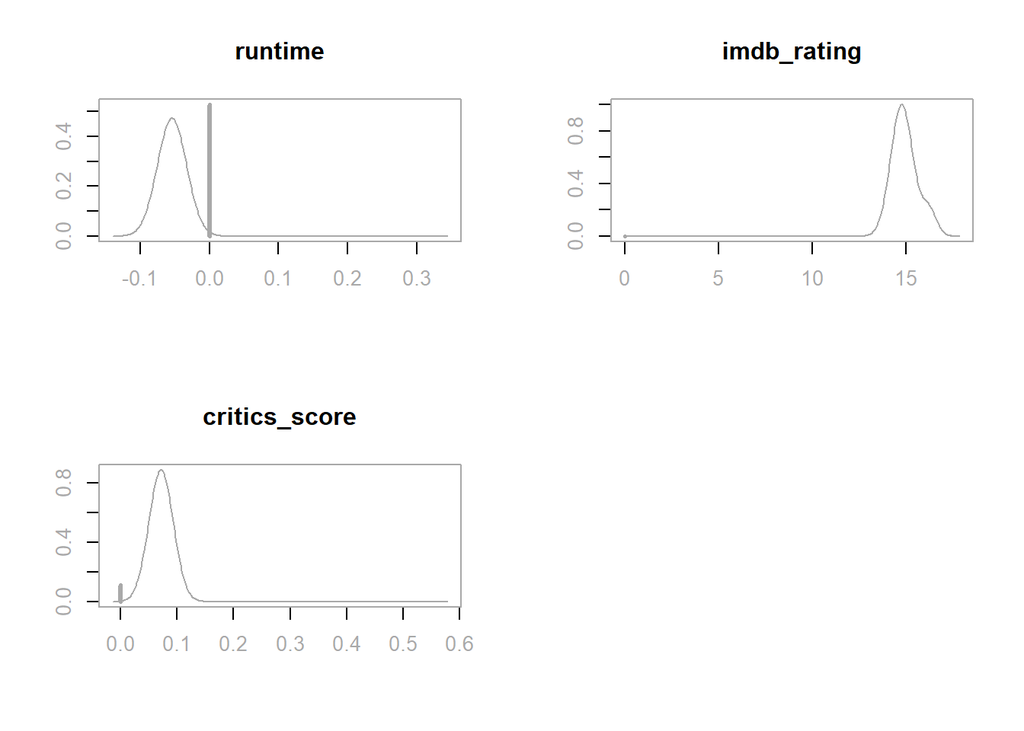

```r
bpm_model_coef <- coef(bpm_model)

par(mfrow = c(2, 2), col.lab = "darkgrey", col.axis = "darkgrey", col = "darkgrey")
plot(bpm_model_coef, subset = 2:4, ask = FALSE)
```

These distributions all center at their respetive OLS estimates, with the spread of the distribution related to the standard errors.

### 3. Interpretation of model coefficients:

95% credible interval of the coefficients:

```r
out = confint(bpm_model_coef)[, 1:2]

# Extract the upper and lower bounds of the credible intervals
names = c("posterior mean", "posterior std", colnames(out))
out = cbind(bpm_model_coef$postmean, bpm_model_coef$postsd, out)
colnames(out) = names

round(out, 2)
```

```
##               posterior mean posterior std  2.5% 97.5%
## Intercept              62.35          0.40 61.57 63.13
## runtime                -0.03          0.03 -0.08  0.00
## imdb_rating            14.96          0.74 13.67 16.57
## critics_score           0.06          0.03  0.00  0.11
```

Based on the 95% credible interval of all the coefficients, we can believe that there is a 95% change that *audience_score* will

## Part 5: Prediction

### 1. Choose the movie:

One of most popular film in 2016: [La la land](https://www.imdb.com/title/tt3783958/)

- runtime: 128
- imdb_rating: 8
- critics_score: 91

```r
new_movie <- data.frame(
  runtime = 128,
  imdb_rating = 8,
  critics_score = 91
)
```

And *audience_score*: 81 ([Rotten Tomatoes](https://www.rottentomatoes.com/m/la_la_land)).  
Let’s see how well our model perform on this new data.

### 2. Predict the *audience_score*:

```r
new_movie_pred <- predict(bpm_model, newdata = new_movie, estimator = 'BMA', se.fit = TRUE)
confint(new_movie_pred)
```

```
##       2.5% 97.5%  pred
## [1,] 66.83 105.7 86.47
## attr(,"Probability")
## [1] 0.95
## attr(,"class")
## [1] "confint.bas"
```

## Part 6: Conclusion

With such positive result, we can say that we successfully built a multivariate Bayesian regression model that can predict the *audience_score* of a movie.  
We also learn that *runtime*, *imdb_rating* and *critics_score* hold most influence on *audience_score*. So the model built with those 3 variables can produce a pretty accurate prediction.

One shortcoming is the practical aspect of the model in predicting *audience_score*.  
*imdb_rating* and *critics_score* are only available after the movie has been released. In other word, *audience_score* will be already available on Rotten Tomatoes when we have those data.

Possible improvements:

- Reconfirm with management on the purpose of the model, how and when will it be used.
- Based on the purpose, reduce the impractical variables, and collect more potential predictors.